# Time Series Canadian Employment

Atika Dewi Suryani

August 21, 2020

**Intro**

```
- Time Series Plots

- Data Transformation and Adjustment

- Decomposition

- Simple Average

- Naive Method

- Time Series Linear Regression

- Simple Exponential Smoothing

- Holt’s Linear Trend

- Holt-Winters’ Seasonal Trend

- ETS

- ARIMA

- Neural Network Autoregression

- Forecast Accuracy Evaluation
```

# Libraries and Setup

```r
library(dplyr)
library(tidyverse)
library(fpp)
library(astsa)
library(DT)
library(dygraphs)
library(lubridate)
```

# Load Data

```r
can <- read.csv("data/canemploy.csv")
head(can)
```

```
##   ï..Month Monthly.Canadian.total.unemployment.figures..thousands..1956.1975
## 1  1956-01                                                               315
## 2  1956-02                                                               340
## 3  1956-03                                                               321
## 4  1956-04                                                               273
## 5  1956-05                                                               175
## 6  1956-06                                                               127
```

**Convert data to `time series`**

```r
can.ts <- ts(can, frequency = 12, start = c(1956,1), end = c(1975,12))
```

# Time Series Plot

The first thing to do with any time seriese analysis is to plot the charts.

It is also a good idea to aggregate monthly production volume into quarterly and yearly volume. Depending on the business questions we try to answer, different time scales can be very useful.

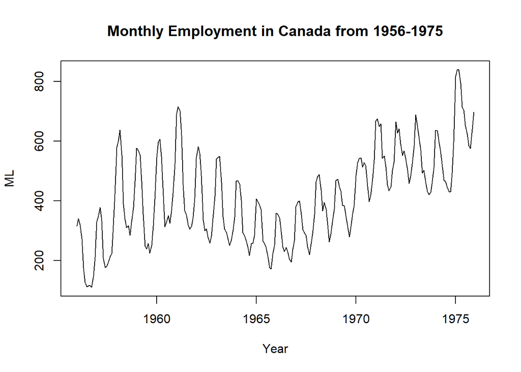

```r
can.ts.qtr <- aggregate(can.ts, nfrequency=4)
can.ts.yr <- aggregate(can.ts, nfrequency=1)
plot.ts(can.ts[,2], main = "Monthly Employment in Canada from 1956-1975", xlab = "Year", ylab = "ML")
```

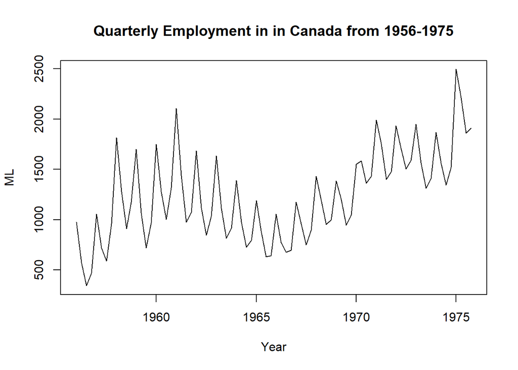

```r
plot.ts(can.ts.qtr[,2], main = "Quarterly Employment in in Canada from 1956-1975", xlab = "Year", ylab = "ML")
```

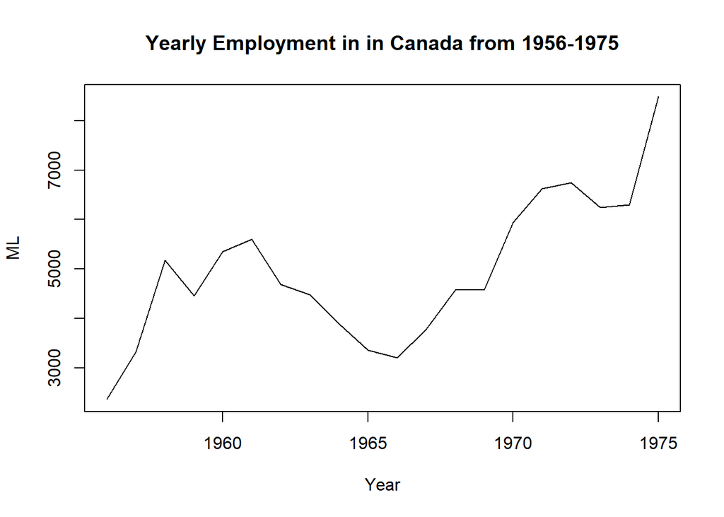

```r
plot.ts(can.ts.yr[,2], main = "Yearly Employment in in Canada from 1956-1975", xlab = "Year", ylab = "ML")
```

**Summary** As we can see there was a strong growth from 1965 to 1975 then the production was slowing increasing with higher volatility. We can also see very strong seasonality which is obvious for the employment.

Next step we want to take a look at seasonality in more detail.

## Data Seasonality

Yearly Plot

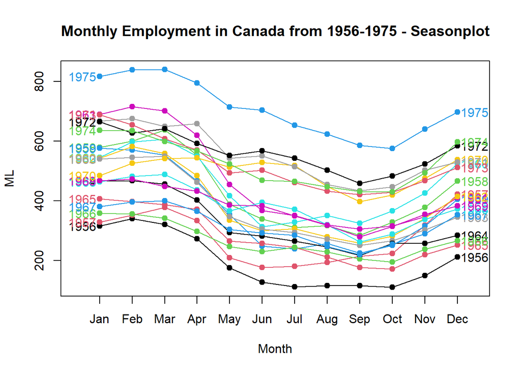

```r
seasonplot(can.ts[,2], year.labels = TRUE, year.labels.left=TRUE, col=1:40, pch=19, main = "Monthly Employment in Canada from 1956-1975 - Seasonplot", xlab = "Month", ylab = "ML", palette = "Dark2")
```

Monthly Plot

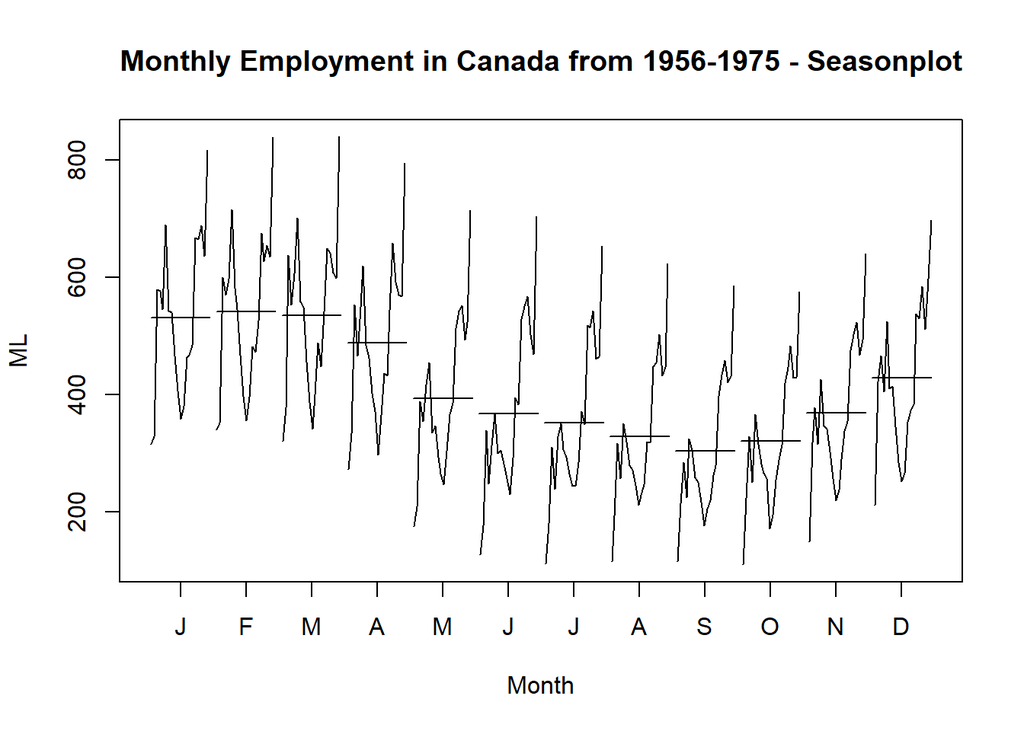

```r
monthplot(can.ts[,2], main = "Monthly Employment in Canada from 1956-1975 - Seasonplot", xlab = "Month", ylab = "ML")
```

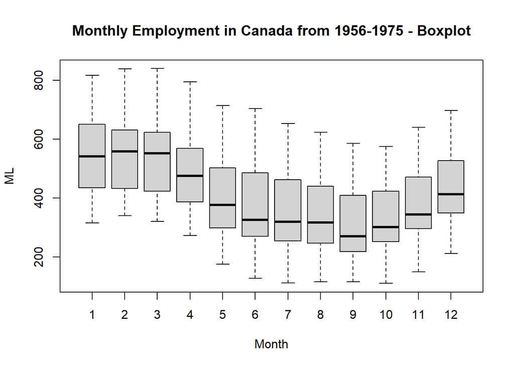

```r
boxplot(can.ts[,2] ~ cycle(can.ts[,2]), xlab = "Month", ylab = "ML", main = "Monthly Employment in Canada from 1956-1975 - Boxplot")
```

**Summary** 3 different charts all give us the level among different months, but also the range and variation. We can also see the variation and range within the same month.

Next, we will look at the trend more closely. Moving average smoothing is a great way to exame the trend. By adjusting how many months to calculate the average, we can control the smoothness of the trend line

## Moving Average

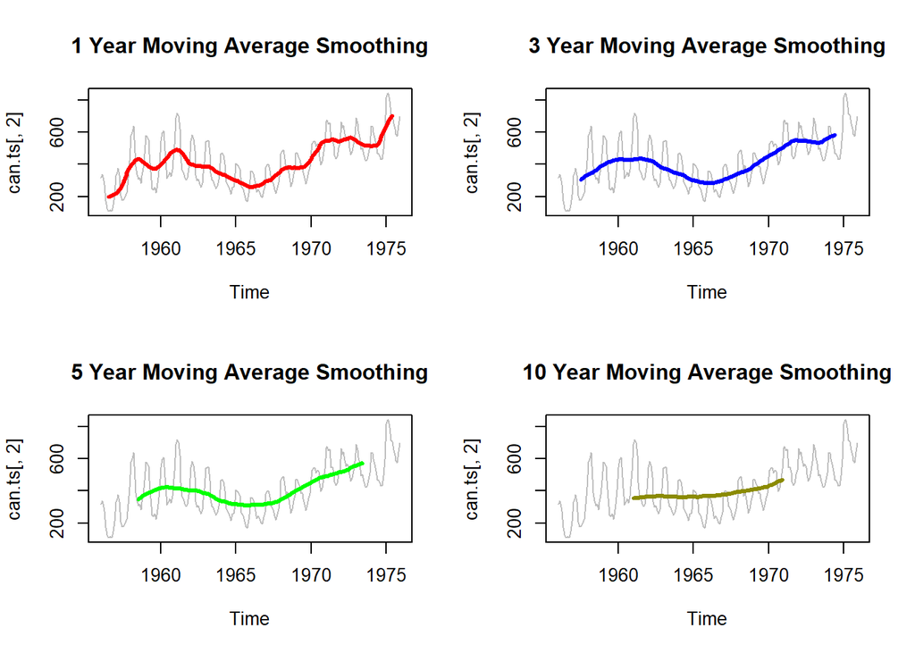

```r
par(mfrow = c(2,2))
plot(can.ts[,2], col="gray", main = "1 Year Moving Average Smoothing")
lines(ma(can.ts[,2], order = 12), col = "red", lwd=3)
plot(can.ts[,2], col="gray", main = "3 Year Moving Average Smoothing")
lines(ma(can.ts[,2], order = 36), col = "blue", lwd=3)
plot(can.ts[,2], col="gray", main = "5 Year Moving Average Smoothing")
lines(ma(can.ts[,2], order = 60), col = "green", lwd=3)
plot(can.ts[,2], col="gray", main = "10 Year Moving Average Smoothing")
lines(ma(can.ts[,2], order = 120), col = "yellow4", lwd=3)
```

# Transformation Adjustment Sometimes, adjusting and transformating data can make the historical data less complex so a simpler forecast model can be used. It is also a good idea to remove the underline factors affected the time series like workday, inflation, population, and currancy exchange rate…ect.

Calendar Adjustment

Sometimes, the variances in monthly data is simple due to the different number of days in each month. If we look at the monthly canada employment data, not only the number of days in each month will impact the employment volume, but number of companies will also have a significant impact as well.

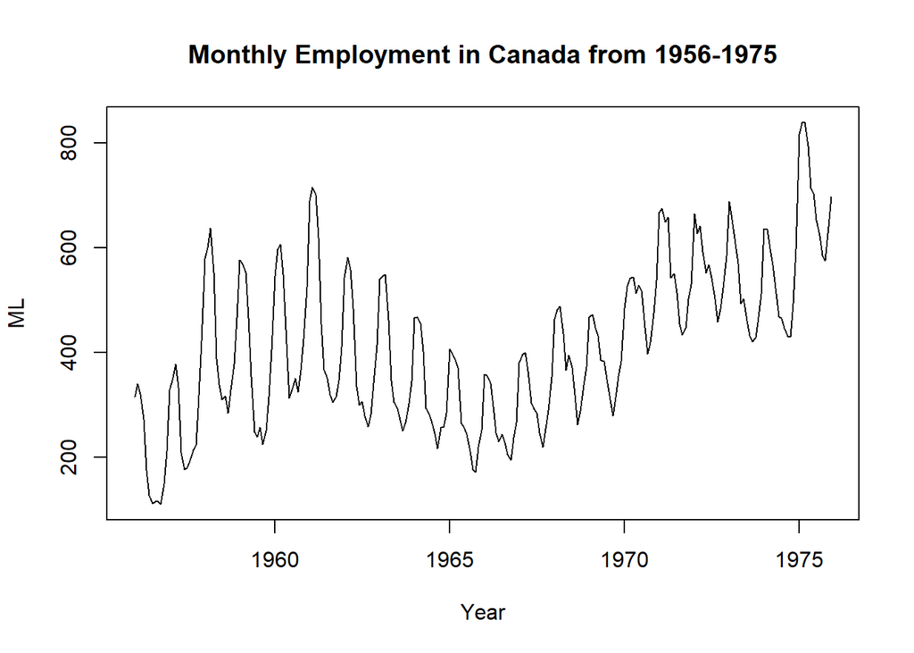

```r
plot.ts(can.ts[,2], main = "Monthly Employment in Canada from 1956-1975", xlab = "Year", ylab = "ML")
```

Logarithm Adjustment

Logarithm transformation is most used mathematical transformation not only in time series but any other regression models or data visualization. In time series analysis, by applying log transformation, it will stablize the variance. Hence transform exponential trend line into a linear line. It is used before differencing data to improve stationarity.

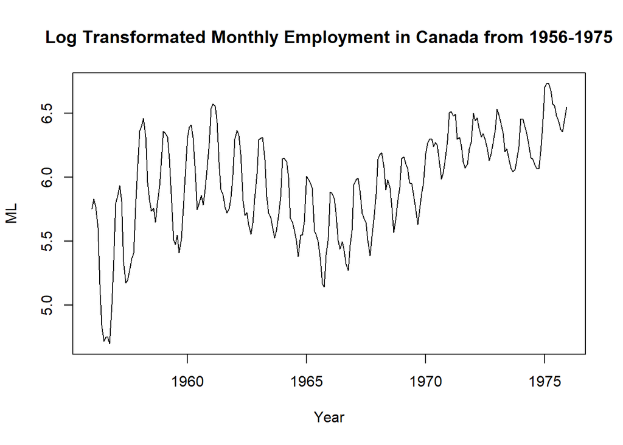

```r
plot.ts(log(can.ts[,2]), main = "Log Transformated Monthly Employment in Canada from 1956-1975", xlab = "Year", ylab = "ML")
```

## Decomposition After just looking at the different plots, we normally can get a good sense on how the time series behaves and the different components within the data. Decomposition is a tool that we can seperate different components in a time series data so we can see trend, seasonality, and random noises individually.

STL Decomposition

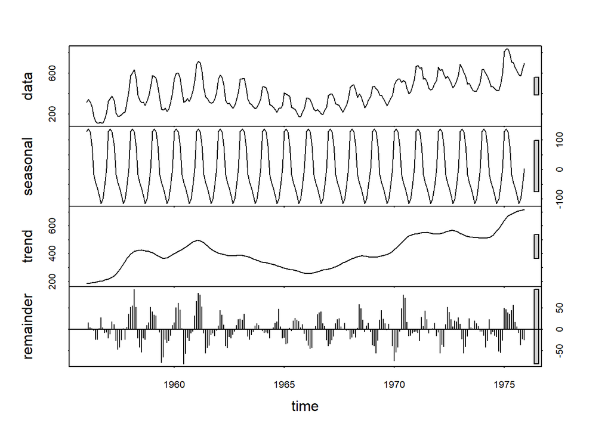

```r
plot(stl(can.ts[,2], s.window="periodic"))
```

**Summary** From this chart, we can see that the seasonaliy is slightly strong but consistant. The trend is similar to what we saw when we aggreciated the data into yearly which is that from 1965 to 1975.

# Basic Models Forecast

- Average : simple average of all data points
- Naive Method : the last observation value
- Seasonal Naive : the last observation value from previous seasonal cycle
- Drift Method : forecast value increase or decrease over time based on average change in historical data

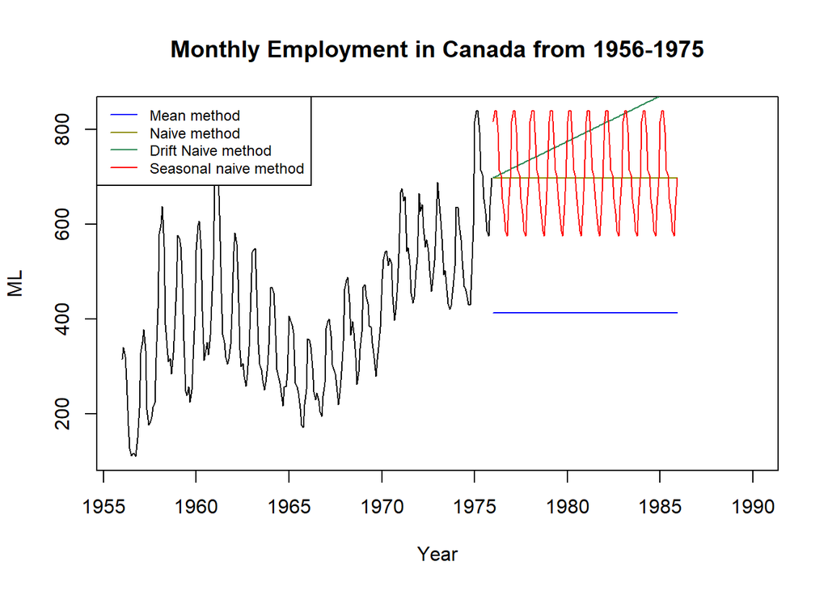

```r
can.fit.a <- meanf(can.ts[,2], h = 120)
can.fit.n <- naive(can.ts[,2], h = 120)
can.fit.sn <- snaive(can.ts[,2], h = 120)
can.fit.dri <- rwf(can.ts[,2], h = 120, drift = TRUE)
plot.ts(can.ts[,2], main = "Monthly Employment in Canada from 1956-1975", xlab = "Year", ylab = "ML", xlim = c(1956, 1990))
lines(can.fit.a$mean, col = "blue")
lines(can.fit.n$mean, col = "yellow4")
lines(can.fit.dri$mean, col = "seagreen4")
lines(can.fit.sn$mean, col = "red")
legend("topleft",lty=1,col=c("blue","yellow4","seagreen4", "red"), cex = 0.75,
       legend=c("Mean method","Naive method","Drift Naive method", "Seasonal naive method"))
```

In this case, all of them are not good models because of the combination of trend and seasonality. However, if you have a less complex time series, these models might be good enough. Plus, these models can also be treated as benchmark when we move to more complex models.

# Regression Analysis

## Forecast with Linear Regression

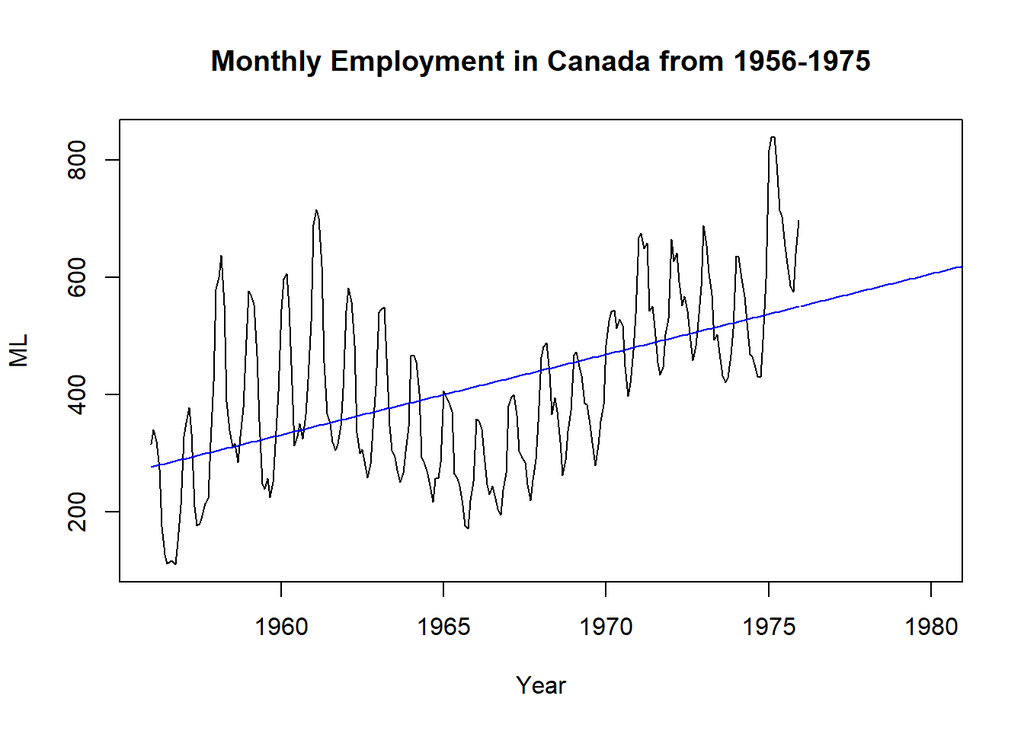

```r
can.fit.lm <- tslm(can.ts[,2] ~ trend)
f <- forecast(can.fit.lm, h = 120, level = c(80,95))
plot.ts(can.ts[,2], main = "Monthly Employment in Canada from 1956-1975", xlab = "Year", ylab = "ML", xlim = c(1956,1980))
lines(f$fitted, col = "blue")
lines(f$mean, col = "blue")
```

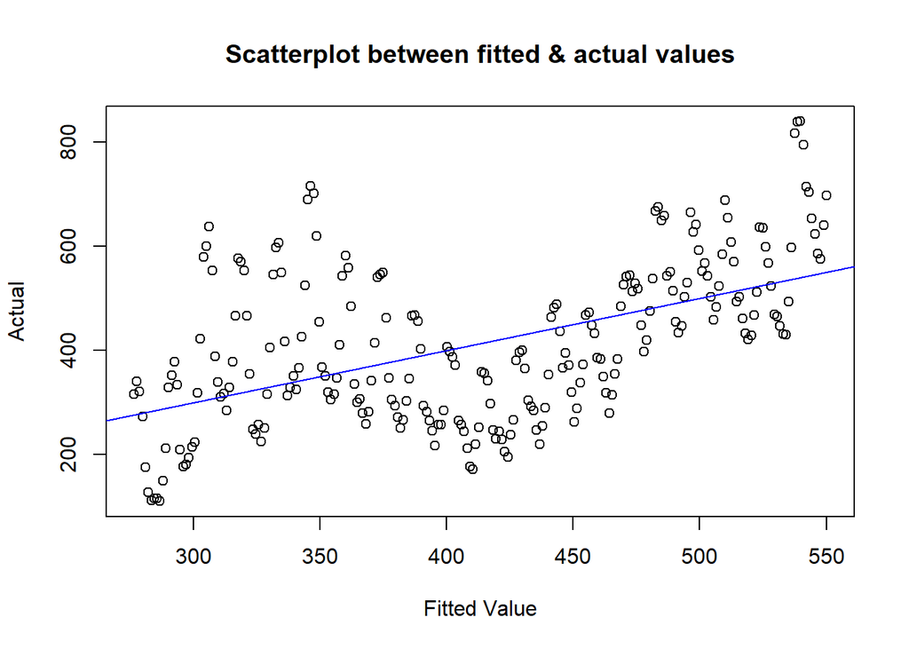

```r
plot(can.fit.lm$fitted, can.ts[,2], main = "Scatterplot between fitted & actual values", xlab = "Fitted Value", ylab = "Actual")
abline(0, 1, col="blue")
```

```r
summary(can.fit.lm)
```

```
##
## Call:
## tslm(formula = can.ts[, 2] ~ trend)
##
## Residuals:
##     Min      1Q  Median      3Q     Max
## -239.42  -88.76  -12.94   72.06  369.70
##
## Coefficients:
##             Estimate Std. Error t value Pr(>|t|)
## (Intercept) 275.3182    16.9408  16.252   <2e-16 ***
## trend         1.1449     0.1219   9.394   <2e-16 ***
## ---
## Signif. codes:  0 '***' 0.001 '**' 0.01 '*' 0.05 '.' 0.1 ' ' 1
##
## Residual standard error: 130.8 on 238 degrees of freedom
## Multiple R-squared:  0.2705, Adjusted R-squared:  0.2674
## F-statistic: 88.24 on 1 and 238 DF,  p-value: < 2.2e-16
```

It did a good job on picking up the trend. However, we know that there is seasonality as well. So we will add another variable into the regression

## Forecast with Linear Regression and Seasonality

```r
can.fit.lm2 <- tslm(can.ts[,2] ~ trend + season)
summary(can.fit.lm2)
```

```
##
## Call:
## tslm(formula = can.ts[, 2] ~ trend + season)
##
## Residuals:
##      Min       1Q   Median       3Q      Max
## -201.615  -77.385   -7.732   64.626  238.932
##
## Coefficients:
##               Estimate Std. Error t value Pr(>|t|)
## (Intercept)  393.82672   24.40005  16.140  < 2e-16 ***
## trend          1.19412    0.09178  13.011  < 2e-16 ***
## season2        9.20588   31.11172   0.296  0.76758
## season3        1.91177   31.11213   0.061  0.95106
## season4      -45.98235   31.11280  -1.478  0.14081
## season5     -141.97646   31.11375  -4.563 8.25e-06 ***
## season6     -170.17058   31.11497  -5.469 1.19e-07 ***
## season7     -186.66469   31.11646  -5.999 7.77e-09 ***
## season8     -210.40881   31.11822  -6.762 1.14e-10 ***
## season9     -237.45292   31.12025  -7.630 6.42e-13 ***
## season10    -221.74704   31.12255  -7.125 1.37e-11 ***
## season11    -174.14115   31.12512  -5.595 6.33e-08 ***
## season12    -115.83527   31.12796  -3.721  0.00025 ***
## ---
## Signif. codes:  0 '***' 0.001 '**' 0.01 '*' 0.05 '.' 0.1 ' ' 1
##
## Residual standard error: 98.38 on 227 degrees of freedom
## Multiple R-squared:  0.6064, Adjusted R-squared:  0.5856
## F-statistic: 29.15 on 12 and 227 DF,  p-value: < 2.2e-16
```

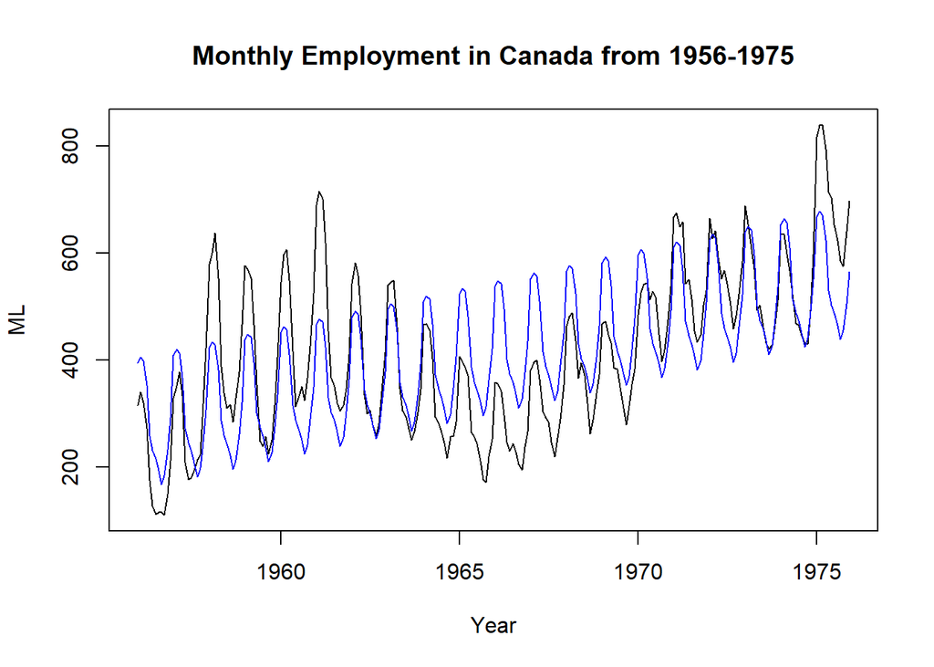

```r
plot.ts(can.ts[,2], main = "Monthly Employment in Canada from 1956-1975", xlab = "Year", ylab = "ML")
lines(can.fit.lm2$fitted.values, col = "blue")
```

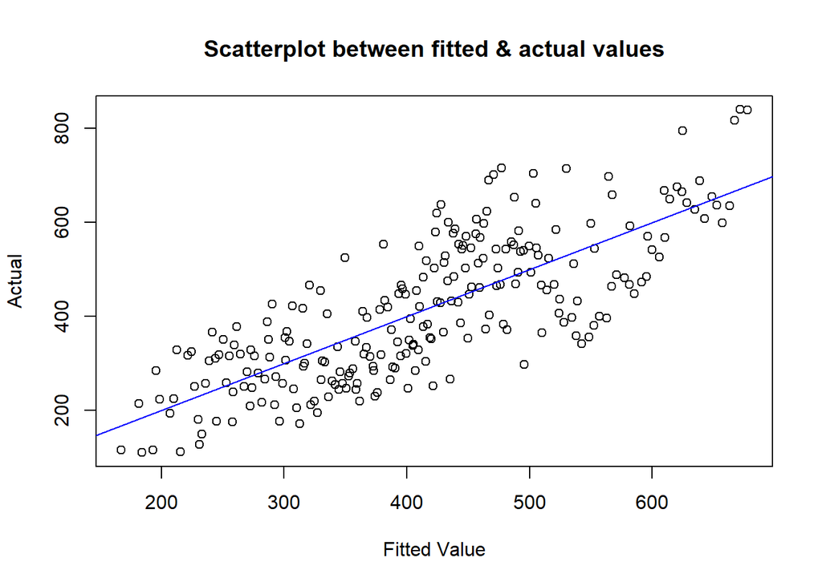

```r
plot(can.fit.lm2$fitted, can.ts[,2], main = "Scatterplot between fitted & actual values", xlab = "Fitted Value", ylab = "Actual")
abline(0, 1, col="blue")
```

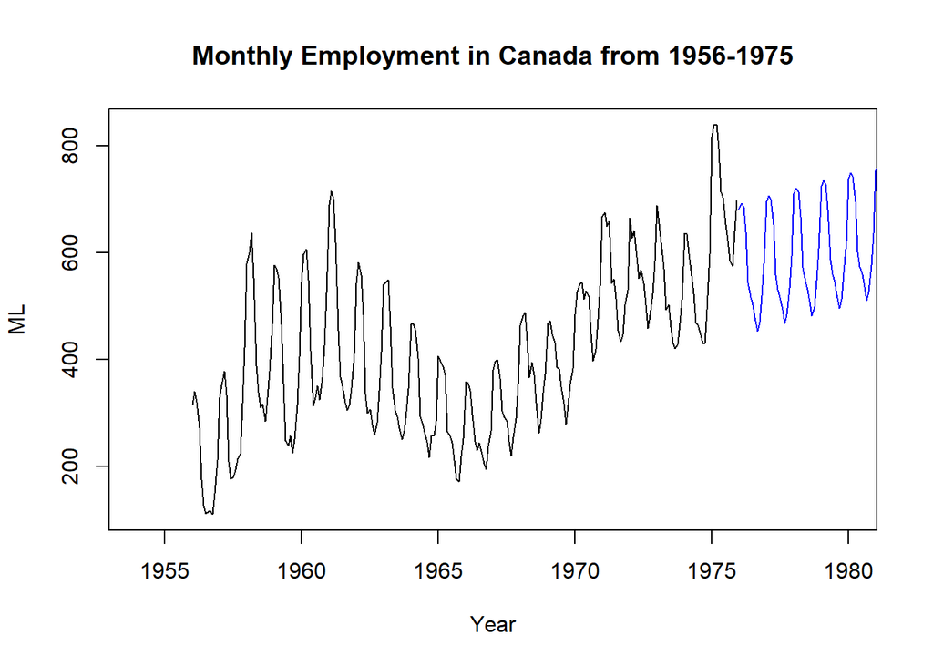

```r
f <- forecast(can.fit.lm2, h = 120, level = c(80,95))
plot.ts(can.ts[,2], main = "Monthly Employment in Canada from 1956-1975", xlab = "Year", ylab = "ML", xlim = c(1954,1980))
lines(f$mean, col = "blue")
```

## Parabola We can see the trend clearly not a straight line. Therefore, we can add a new input variable t^2 to create a parabola.

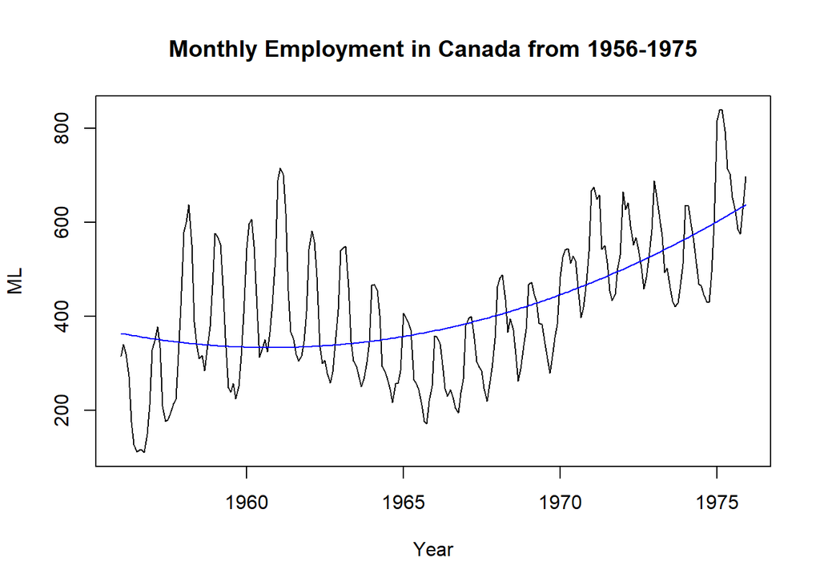

```r
t <- seq(1956, 1995.2, length = length(can.ts[,2]))
t2 <- t^2
can.fit.lm3 <- tslm(can.ts[,2] ~ t + t2)
plot.ts(can.ts[,2], main = "Monthly Employment in Canada from 1956-1975", xlab = "Year", ylab = "ML")
lines(can.fit.lm3$fit, col = "blue")
```

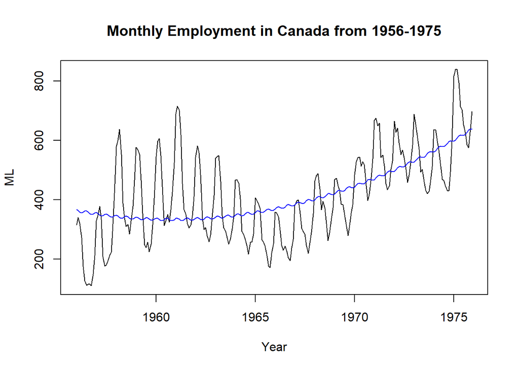

```r
sin.t <- sin(2*pi*t)
cos.t <- cos(2*pi*t)
can.fit.lm4 <- tslm(can.ts[,2] ~ t + t2 + sin.t + cos.t)
plot.ts(can.ts[,2], main = "Monthly Employment in Canada from 1956-1975", xlab = "Year", ylab = "ML")
lines(can.fit.lm4$fit, col = "blue")
```

# Exponential Smoothing

Exponential smoothing is basically taking weighted average of previoud observations. By adjusting alpha, beta, and gamma parameters, we can control the weights for level, trend, and seasonality.

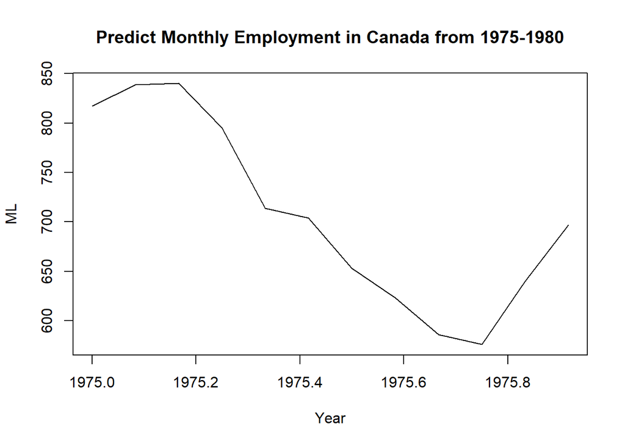

```r
can.ts2 <- window(can.ts, start = 1975)
plot.ts(can.ts2[,2], main = "Predict Monthly Employment in Canada from 1975-1980", xlab = "Year", ylab = "ML")
```

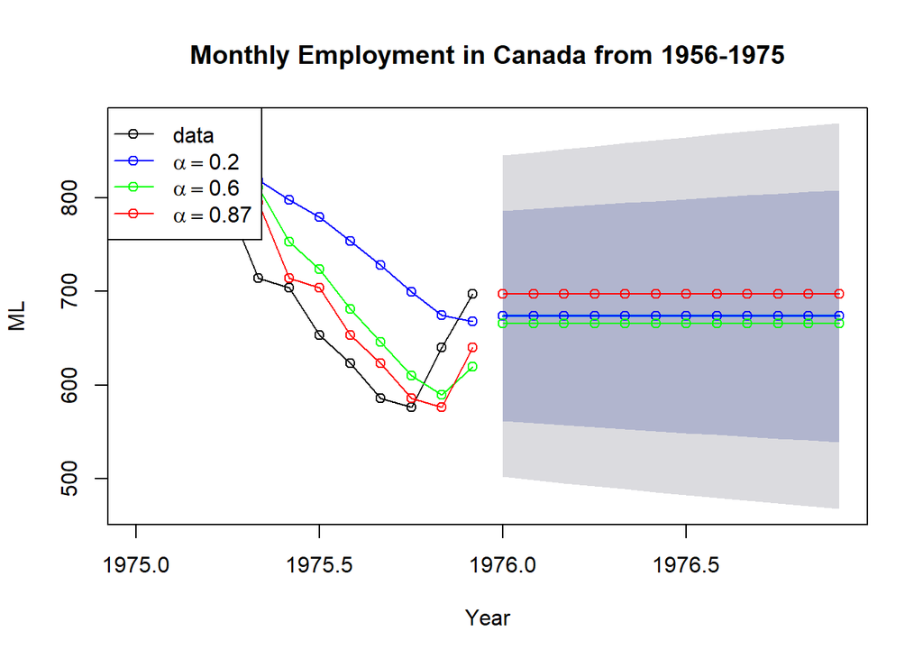

```r
can.fit.ses1 <- ses(can.ts2[,2], alpha = 0.2, initial = "simple", h = 12)
can.fit.ses2 <- ses(can.ts2[,2], alpha = 0.6, initial = "simple", h = 12)
can.fit.ses3 <- ses(can.ts2[,2], h = 12)
plot(can.fit.ses1, plot.conf=FALSE, type="o", main = "Monthly Employment in Canada from 1956-1975", xlab = "Year", ylab = "ML")
lines(can.fit.ses1$fitted, col = "blue", type="o")
lines(can.fit.ses2$fitted, col = "green", type="o")
lines(can.fit.ses3$fitted, col = "red", type="o")
lines(can.fit.ses1$mean, col = "blue", type="o")
lines(can.fit.ses2$mean, col = "green", type="o")
lines(can.fit.ses3$mean, col = "red", type="o")
legend("topleft",lty=1, col=c(1,"blue","green","red"),
       c("data", expression(alpha == 0.2), expression(alpha == 0.6),
         expression(alpha == 0.87)), pch = 1)
```

Simple exponential smoothing only conside level. so, we now will use another model that can capture trend as well.

## Holt’s Linear Trend Method

In the Holt’s linear trend models, there are 3 variations.

```
- Holt’s Linear Trend

- Expontential Linear Trend - The level and slop are mutipled instead of added in Holt’s model

- Damped Trend - The trend became flat after a period increase or decrease. It is usually very useful in the business world since typical growth or decline will stop after a certain period of time.
```

```r
can.ts.yrl <- aggregate(can.ts, nfrequency=1)
can.ts.yrl <- window(can.ts.yrl , start = 1956, end = 1975)
can.fit.holt1 <- holt(can.ts.yrl[,2], alpha = 0.2, beta = 0.2, initial = "simple", h = 6)
can.fit.holt2 <- holt(can.ts.yrl[,2], alpha = 0.2, beta = 0.2, initial = "simple", exponential = TRUE, h = 6)
can.fit.holt3 <- holt(can.ts.yrl[,2], alpha = 0.2, beta = 0.2, initial = "simple", damped = TRUE, h = 6)
```

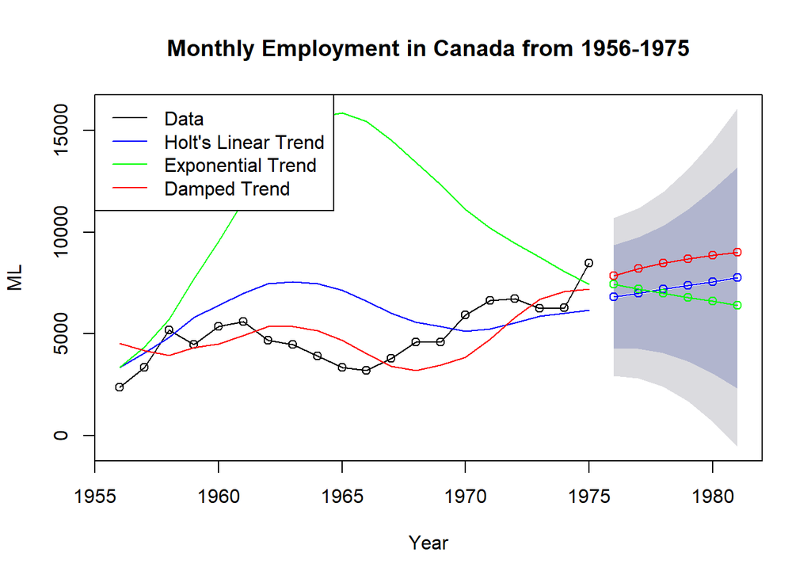

```r
## "simple", : Damped Holt's method requires optimal initialization

plot(can.fit.holt1, type="o", fcol="white", main = "Monthly Employment in Canada from 1956-1975", xlab = "Year", ylab = "ML", plot.conf=FALSE)
lines(can.fit.holt1$fitted, col = "blue")
lines(can.fit.holt2$fitted, col = "green")
lines(can.fit.holt3$fitted, col = "red")
lines(can.fit.holt1$mean, col = "blue", type="o")
lines(can.fit.holt2$mean, col = "green", type="o")
lines(can.fit.holt3$mean, col = "red", type="o")
legend("topleft", lty = 1, col = c("black", "blue", "green", "red"),
       c("Data", "Holt's Linear Trend", "Exponential Trend", "Damped Trend"))
```

## Holt-Winters’ Seasonal Trend

This is an extention from Holt’s model by adding seasonal parameter to capture seasonality

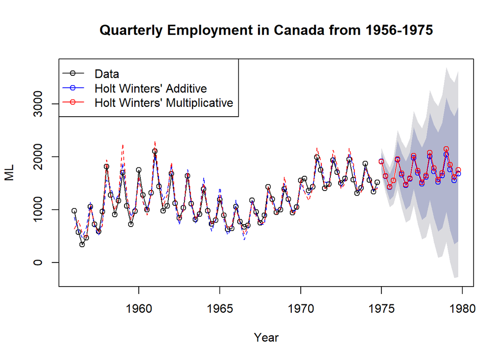

```r
can.ts3 <- window(can.ts, start = 1956, end = 1975)
can.ts.qtr <- aggregate(can.ts3, nfrequency=4)
can.fit.hw1 <- hw(can.ts.qtr[,2], h = 20, seasonal = "additive")
can.fit.hw2 <- hw(can.ts.qtr[,2], h = 20, seasonal = "multiplicative")

plot(can.fit.hw1, type="o", fcol="white", main = "Quarterly Employment in Canada from 1956-1975", xlab = "Year", ylab = "ML", plot.conf=FALSE)
lines(can.fit.hw1$fitted, col = "blue", lty=2)
lines(can.fit.hw2$fitted, col = "red", lty=2)
lines(can.fit.hw1$mean, col = "blue", type="o")
lines(can.fit.hw2$mean, col = "red", type="o")
legend("topleft", lty = 1, pch = 1, col = c("black", "blue", "red"),
       c("Data", "Holt Winters' Additive", "Holt Winters' Multiplicative"))
```

## ETS People often feel overwhelmed by which model to use since there are 30 different models to choose from. Luckly, the ETS function in R helps us to estimate the best model which is the one with least AIC score

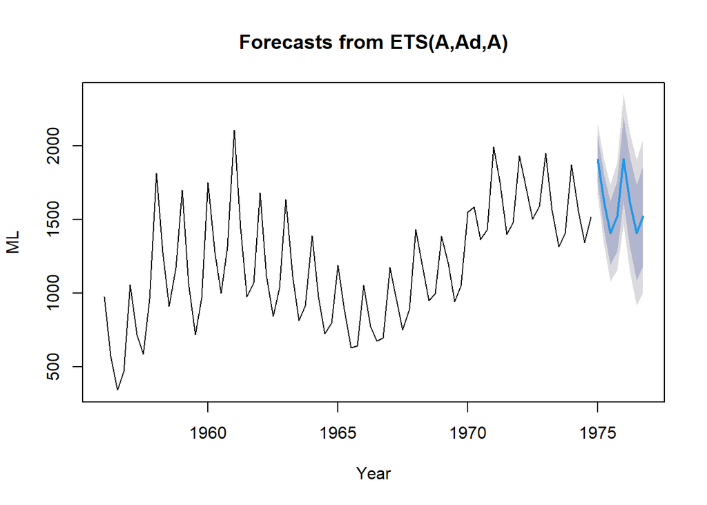

```r
can.fit.ets <- ets(can.ts.qtr[,2])
plot(forecast((can.fit.ets), h = 8), xlab = "Year", ylab = "ML")
```

```r
summary(can.fit.ets)
```

```
## ETS(A,Ad,A)
##
## Call:
##  ets(y = can.ts.qtr[, 2])
##
##   Smoothing parameters:
##     alpha = 0.64
##     beta  = 0.007
##     gamma = 0.36
##     phi   = 0.9017
##
##   Initial states:
##     l = 356.9847
##     b = 93.1886
##     s = -140.9371 -262.7864 14.2878 389.4358
##
##   sigma:  123.0542
##
##      AIC     AICc      BIC
## 1071.076 1074.460 1094.383
##
## Training set error measures:
##                    ME     RMSE      MAE      MPE     MAPE      MASE      ACF1
## Training set 6.772699 115.5386 89.63838 0.393714 8.111192 0.5201454 0.4054977
```

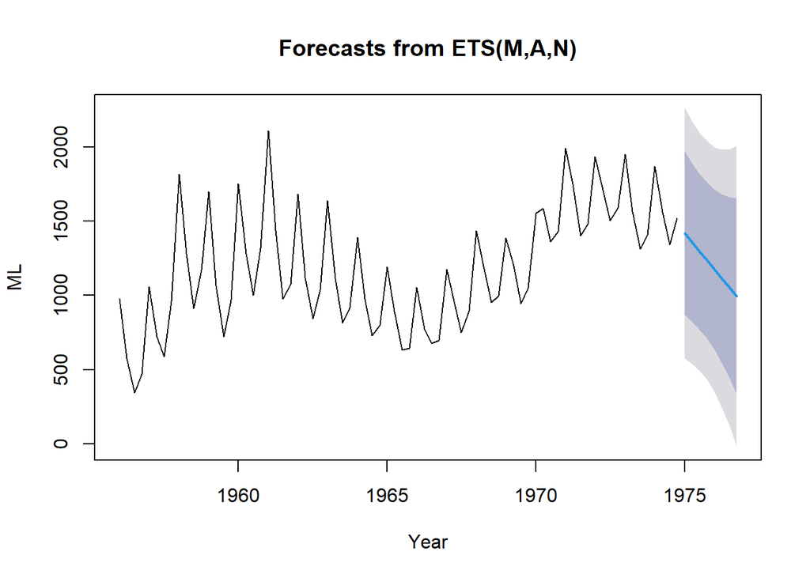

```r
can.fit.ets2 <- ets(can.ts.qtr[,2], model = "MAN")
plot(forecast((can.fit.ets2), h = 8), xlab = "Year", ylab = "ML")
```

```r
summary(can.fit.ets2)
```

```
## ETS(M,A,N)
##
## Call:
##  ets(y = can.ts.qtr[, 2], model = "MAN")
##
##   Smoothing parameters:
##     alpha = 0.0696
##     beta  = 0.0696
##
##   Initial states:
##     l = 434.0268
##     b = 87.9928
##
##   sigma:  0.3036
##
##      AIC     AICc      BIC
## 1227.372 1228.229 1239.026
##
## Training set error measures:
##                     ME     RMSE      MAE       MPE     MAPE     MASE      ACF1
## Training set -28.05168 314.0675 255.5124 -8.292544 24.10249 1.482664 0.1500311
```

It is obvious that Holt’t trend only model will not do as well as seasonality model given the highly seasonal trend in our data. It can be proved by looking at the AIC for these two models. AIC for Holt’s trend model is 1227.372 compared to 1071.076 from estimate model.

# ARIMA

## Autocorrelation

Autoccorrelation is basically to see if the consecutive observations are correlated. If there is correlation, we can run a regression using current observation as depending variable and previous observation as indenpending variable.

There a couple of ways to help to see if there is correlation between lags.

```r
cor_can <- cbind(can.ts[-1,2], can.ts[-468,2])
head(cor_can)
```

```
##      [,1] [,2]
## [1,]  340  315
## [2,]  321  340
## [3,]  273  321
## [4,]  175  273
## [5,]  127  175
## [6,]  112  127
```

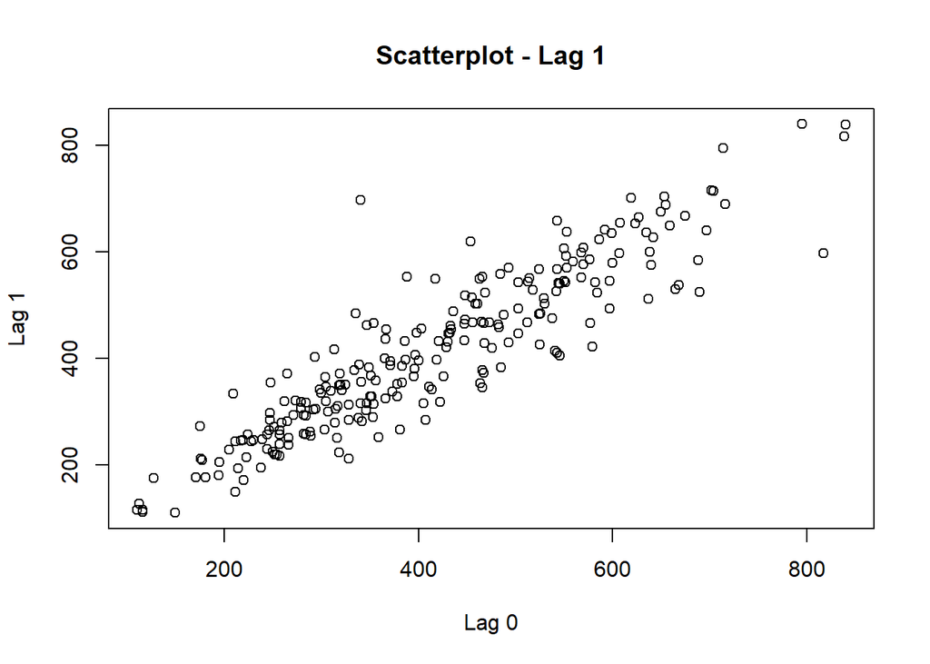

```r
plot(cor_can, main = "Scatterplot - Lag 1", xlab = "Lag 0", ylab = "Lag 1")
```

```r
cor(cor_can)
```

```
##           [,1]      [,2]
## [1,] 1.0000000 0.9111004
## [2,] 0.9111004 1.0000000
```

As we can see there is correlation of 1 and 0.9 which means there is strong relationship between consecutive observations.

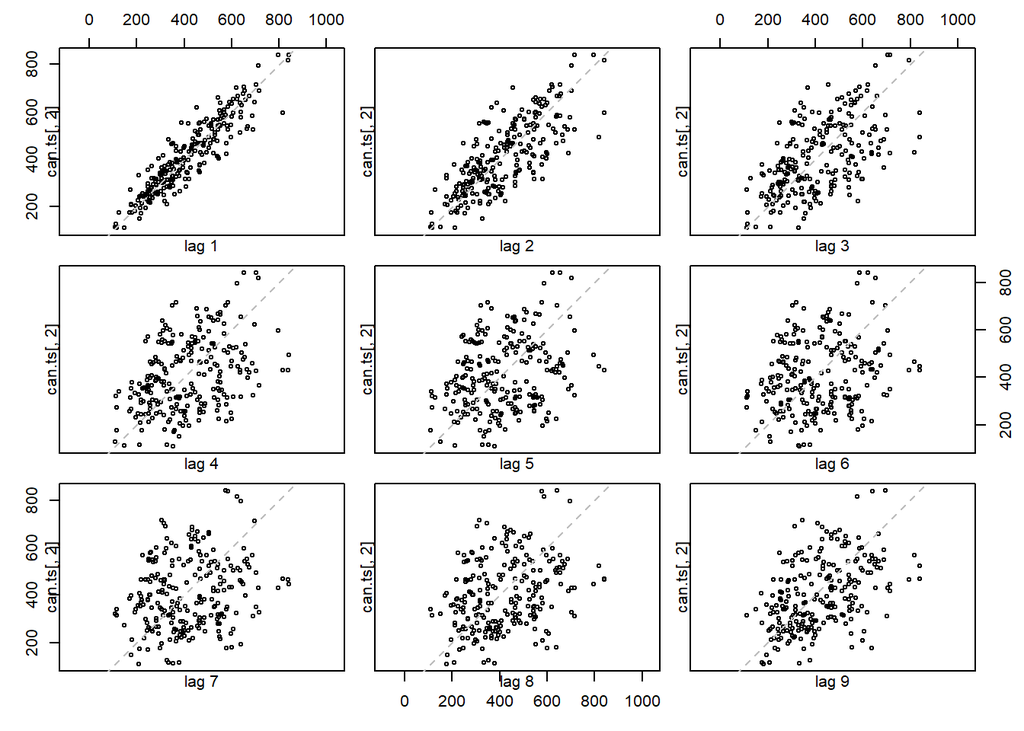

```r
lag.plot(can.ts[,2], lags = 9, do.lines = FALSE)
```

We can see the correlation is declining from lag 1 to lag 7 which makes sense since the correlation normally diminished by time. We can also see seasonality affect here since the correlation is worse from lag 5 to lag 8 than from lag 9.

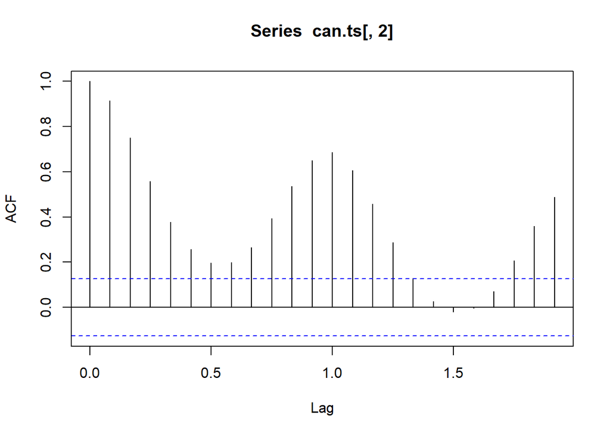

```r
acf(can.ts[,2])
```

## Differencing

Differencing computes the differences between consecutive observations. By differencing the time series data, we can remove the trend and seasonality.8

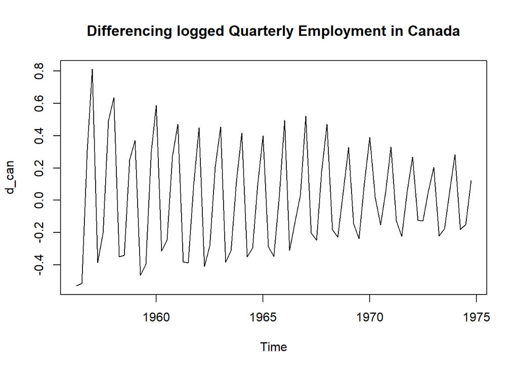

```r
d_can <- diff(log(can.ts.qtr[,2]))
plot(d_can, main = "Differencing logged Quarterly Employment in Canada")
```

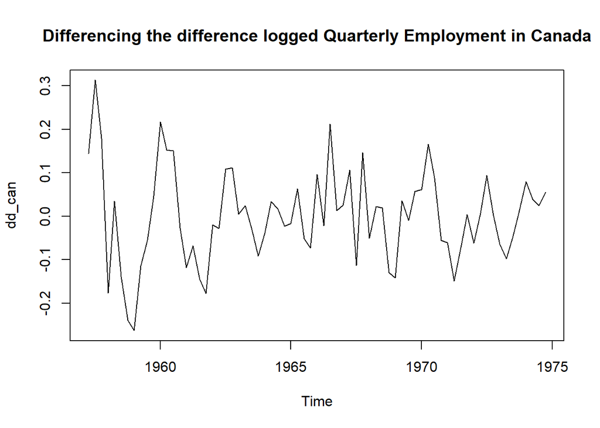

```r
dd_can <- diff(d_can, lag = 4)
plot(dd_can, main = "Differencing the difference logged Quarterly Employment in Canada")
```

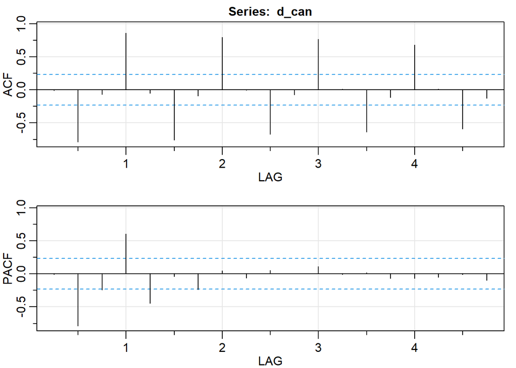

```
##       [,1]  [,2]  [,3] [,4]  [,5]  [,6]  [,7] [,8]  [,9] [,10] [,11] [,12]
## ACF  -0.01 -0.78 -0.07 0.86 -0.05 -0.76 -0.09 0.80 -0.01 -0.67 -0.07  0.76
## PACF -0.01 -0.78 -0.24 0.61 -0.45 -0.04 -0.24 0.05 -0.07  0.05  0.00  0.11
##      [,13] [,14] [,15] [,16] [,17] [,18] [,19]
## ACF   0.01 -0.64 -0.11  0.68  0.01 -0.59 -0.13
## PACF -0.01  0.02 -0.07 -0.07 -0.05 -0.01 -0.10
```

```r
acf2(d_can)
```

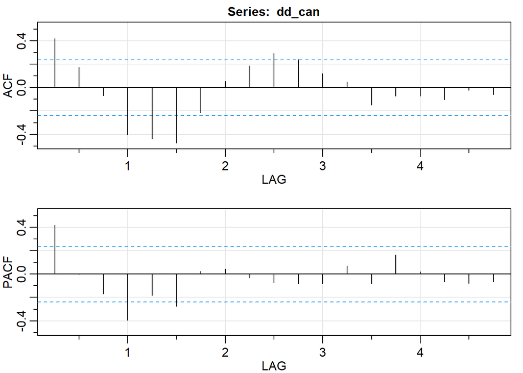

```
##      [,1] [,2]  [,3]  [,4]  [,5]  [,6]  [,7] [,8]  [,9] [,10] [,11] [,12] [,13]
## ACF  0.42 0.17 -0.07 -0.40 -0.44 -0.48 -0.22 0.05  0.19  0.30  0.24  0.12  0.05
## PACF 0.42 0.00 -0.17 -0.39 -0.18 -0.28  0.02 0.04 -0.03 -0.07 -0.08 -0.08  0.07
##      [,14] [,15] [,16] [,17] [,18] [,19]
## ACF  -0.15 -0.07 -0.07 -0.10 -0.02 -0.06
## PACF -0.08  0.16  0.02 -0.07 -0.08 -0.07
```

```r
acf2(dd_can)
```